# TFM

Jia Lin

2025-04-19

## Data Preprocessing

```r
library(readxl)
library(dplyr)
library(janitor)
library(mitools)
library(gsynth)
library(CausalImpact)
library(tibble)
library(plm)
```

```r
library(lmtest)
library(ggplot2)
library(sandwich)
library(mice)
library(corrplot)
library(lubridate)
library(tidyr)
library(synthdid)
library(Synth)
library(estimatr)
```

```r
haryana <- read_excel("Groundwater_Haryana 2017-2022.xlsx")
punjab <- read_excel("Groundwater_punjab 2017 to 2022.xlsx")
```

1. Which districts are included?

```r
haryana_districts <- haryana %>%
  distinct(`District Name`) %>%
  arrange(`District Name`)
cat("Haryana has", nrow(haryana_districts), "districts:\n")
```

```
## Haryana has 20 districts:
```

```r
print(haryana_districts)
```

```
## # A tibble: 20 × 1
##    `District Name`
##    <chr>
##  1 Ambala
##  2 Bhiwani
##  3 Charkhi Dadri
##  4 Faridabad
##  5 Fatehabad
##  6 Hisar
##  7 Jhajjar
##  8 Jind
##  9 Kaithal
## 10 Karnal
## 11 Kurukshetra
## 12 Mahendragarh
## 13 Palwal
## 14 Panchkula
## 15 Panipat
## 16 Rewari
## 17 Rohtak
## 18 Sirsa
## 19 Sonipat
## 20 Yamunanagar
```

```r
punjab_districts <- punjab %>%
  distinct(`District Name`) %>%
  arrange(`District Name`)
cat("\nPunjab has", nrow(punjab_districts), "districts:\n")
```

```
##
## Punjab has 17 districts:
```

```r
print(punjab_districts)
```

```
## # A tibble: 17 × 1
##    `District Name`
##    <chr>
##  1 Amritsar
##  2 Barnala
##  3 Bathinda
##  4 Faridkot
##  5 Fatehgarh Sahib
##  6 Fazilka
##  7 Gurdaspur
##  8 Hoshiarpur
##  9 Jalandhar
## 10 Kapurthala
## 11 Ludhiana
## 12 Mansa
## 13 Moga
## 14 Pathankot
## 15 Patiala
## 16 Sangrur
## 17 Tarn Taran
```

2. What is the time span for each district?

```r
combined <- bind_rows(haryana, punjab)
combined <- combined %>%
  mutate(year = as.numeric(`Date Collection`),
         post = ifelse(year >= 2020, 1, 0)) %>%
  relocate(post, .before = 1)
head(combined)
```

```
## # A tibble: 6 × 103
##    post `Station Name` `Agency Name` `State Name` `District Name` `Basin Name`
##   <dbl> <chr>          <chr>         <chr>        <chr>           <chr>
## 1     1 Abdullapur     CGWB          Haryana      Panchkula       Indus (Up to …
## 2     0 Achheja        CGWB          Haryana      Palwal          Ganga Basin
## 3     0 Achheja        CGWB          Haryana      Palwal          Ganga Basin
## 4     0 Achheja        CGWB          Haryana      Palwal          Ganga Basin
## 5     1 Achheja        CGWB          Haryana      Palwal          Ganga Basin
## 6     1 Achheja        CGWB          Haryana      Palwal          Ganga Basin
## # ℹ 97 more variables: `Sub Basin Name` <chr>, `Date Collection` <chr>,
## #   Longitude <dbl>, Latitude <dbl>, caco3 <chr>, pH_Field <chr>,
## #   `Mg Caco3` <lgl>, Tritium <chr>, `Solids(Total)` <chr>, `PCB-1242` <chr>,
## #   `Fecal Streptococci (MPN/100ml)` <chr>, Barium <chr>, Odour <chr>,
## #   `Ammonia-N (mg/L)` <chr>, `Nitrogen,Organic` <chr>,
## #   `Calcium Hardness (mg/L)` <chr>, `Phosphorus(Total)` <chr>,
## #   `Dissolved Oxygen (mg/L)` <chr>, …
```

```r
district_year_unique <- combined %>%
  mutate(`Date Collection` = as.numeric(`Date Collection`)) %>%
  distinct(`State Name`, `District Name`, `Date Collection`) %>%
  mutate(post = ifelse(`Date Collection` >= 2020, 1, 0))
district_year_unique
```

```
## # A tibble: 213 × 4
##    `State Name` `District Name` `Date Collection`  post
##    <chr>        <chr>                       <dbl> <dbl>
##  1 Haryana      Panchkula                    2022     1
##  2 Haryana      Palwal                       2017     0
##  3 Haryana      Palwal                       2018     0
##  4 Haryana      Palwal                       2019     0
##  5 Haryana      Palwal                       2020     1
##  6 Haryana      Palwal                       2022     1
##  7 Haryana      Hisar                        2017     0
##  8 Haryana      Hisar                        2018     0
##  9 Haryana      Hisar                        2022     1
## 10 Haryana      Fatehabad                    2017     0
## # ℹ 203 more rows
```

```r
district_post_pre_counts <- district_year_unique %>%
  group_by(`State Name`, `District Name`, post) %>%
  summarise(n_years = n(), .groups = "drop") %>%
  tidyr::pivot_wider(
    names_from = post,
    values_from = n_years,
    names_prefix = "post_"
  ) %>%
  rename(pre_years = post_0, post_years = post_1) %>%
  replace_na(list(pre_years = 0, post_years = 0))
district_post_pre_counts
```

```
## # A tibble: 37 × 4
##    `State Name` `District Name` pre_years post_years
##    <chr>        <chr>               <int>      <int>
##  1 Haryana      Ambala                  3          3
##  2 Haryana      Bhiwani                 3          3
##  3 Haryana      Charkhi Dadri           3          2
##  4 Haryana      Faridabad               3          3
##  5 Haryana      Fatehabad               3          3
##  6 Haryana      Hisar                   3          3
##  7 Haryana      Jhajjar                 3          3
##  8 Haryana      Jind                    3          3
##  9 Haryana      Kaithal                 3          3
## 10 Haryana      Karnal                  3          3
## # ℹ 27 more rows
```

```r
districts_to_keep <- district_post_pre_counts %>%
  filter(pre_years >= 3 & post_years >= 3) %>%
  select(`State Name`, `District Name`)
districts_to_keep
```

```
## # A tibble: 33 × 2
##    `State Name` `District Name`
##    <chr>        <chr>
##  1 Haryana      Ambala
##  2 Haryana      Bhiwani
##  3 Haryana      Faridabad
##  4 Haryana      Fatehabad
##  5 Haryana      Hisar
##  6 Haryana      Jhajjar
##  7 Haryana      Jind
##  8 Haryana      Kaithal
##  9 Haryana      Karnal
## 10 Haryana      Kurukshetra
## # ℹ 23 more rows
```

```r
combined <- combined %>%
  semi_join(districts_to_keep, by = c("State Name", "District Name"))
print(combined)
```

```
## # A tibble: 2,472 × 103
##     post `Station Name` `Agency Name` `State Name` `District Name` `Basin Name`
##    <dbl> <chr>          <chr>         <chr>        <chr>           <chr>
##  1     1 Abdullapur     CGWB          Haryana      Panchkula       Indus (Up to…
##  2     0 Achheja        CGWB          Haryana      Palwal          Ganga Basin
##  3     0 Achheja        CGWB          Haryana      Palwal          Ganga Basin
##  4     0 Achheja        CGWB          Haryana      Palwal          Ganga Basin
##  5     1 Achheja        CGWB          Haryana      Palwal          Ganga Basin
##  6     1 Achheja        CGWB          Haryana      Palwal          Ganga Basin
##  7     0 Adampur S      CGWB          Haryana      Hisar           Area of Inla…
##  8     0 Adampur S      CGWB          Haryana      Hisar           Area of Inla…
##  9     1 Adampur S      CGWB          Haryana      Hisar           Area of Inla…
## 10     0 Agroha         CGWB          Haryana      Hisar           Area of Inla…
## # ℹ 2,462 more rows
## # ℹ 97 more variables: `Sub Basin Name` <chr>, `Date Collection` <chr>,
## #   Longitude <dbl>, Latitude <dbl>, caco3 <chr>, pH_Field <chr>,
## #   `Mg Caco3` <lgl>, Tritium <chr>, `Solids(Total)` <chr>, `PCB-1242` <chr>,
## #   `Fecal Streptococci (MPN/100ml)` <chr>, Barium <chr>, Odour <chr>,
## #   `Ammonia-N (mg/L)` <chr>, `Nitrogen,Organic` <chr>,
## #   `Calcium Hardness (mg/L)` <chr>, `Phosphorus(Total)` <chr>, …
```

```r
combined %>%
  distinct(`State Name`, `District Name`) %>%
  count(`State Name`, name = "n_districts")
```

```
## # A tibble: 2 × 2
##   `State Name` n_districts
##   <chr>              <int>
## 1 Haryana               19
## 2 Punjab                14
```

```r
excluded_districts <- bind_rows(haryana, punjab) %>%
  distinct(`State Name`, `District Name`) %>%
  anti_join(districts_to_keep, by = c("State Name", "District Name")) |>
  pull(`District Name`)
excluded_districts
```

```
## [1] "Charkhi Dadri" "Tarn Taran"    "Moga"          "Barnala"
```

In my dataset, each district contains multiple water quality monitoring stations, and each station is theoretically measured once per year. This means that a single district may have several records for the same year. To determine whether a district actually has data in a given year, I kept only one record per district per year—removing duplicates—to avoid overcounting caused by having multiple stations. This gives a more accurate picture of data availability at the district level.

## Data cleaning

```r
haryana[haryana == "-"] <- NA
punjab[punjab == "-"] <- NA
cols_to_drop <- c("Basin Name", "Sub Basin Name", "Agency Name")
haryana <- haryana[, !colnames(haryana) %in% cols_to_drop]
punjab  <- punjab[,  !colnames(punjab)  %in% cols_to_drop]
```

Replacing all “-” entries in the haryana and punjab datasets with NA (missing values).

```r
haryana <- haryana[, colSums(!is.na(haryana)) > 0]
punjab <- punjab[, colSums(!is.na(punjab)) > 0]
```

Removing columns in the haryana and punjab datasets that contain only NA values.

```r
na_ratio_haryana <- colMeans(is.na(haryana))
na_ratio_punjab  <- colMeans(is.na(punjab))
threshold <- 0.6
cols_haryana <- names(na_ratio_haryana)[na_ratio_haryana <= threshold]
cols_punjab <- names(na_ratio_punjab)[na_ratio_punjab <= threshold]

keep_cols <- intersect(cols_haryana, cols_punjab)

haryana <- haryana[, keep_cols]
punjab <- punjab[, keep_cols]

sort(colMeans(is.na(haryana)), decreasing = TRUE)
```

```
##                              Iron (mg/L)
##                             0.5705169113
##                         Carbonate (mg/L)
##                             0.3075941289
##                          Sulphate (mg/L)
##                             0.2922782387
##                   Silicate (SiO2) (mg/L)
##                             0.1518825782
##                    Total Hardness (mg/L)
##                             0.1416719847
##                         Potassium (mg/L)
##                             0.0625398851
##                         Magnesium (mg/L)
##                             0.0612635609
##                           Calcium (mg/L)
##                             0.0599872368
##                       Bicarbonate (mg/L)
##                             0.0599872368
##                            Sodium (mg/L)
##                             0.0599872368
##                          Fluoride (mg/L)
##                             0.0280791321
##                          Chloride (mg/L)
##                             0.0261646458
##                                       pH
##                             0.0012763242
## Electrical Conductivity (µS/cm) at 25°C)
##                             0.0006381621
##                             Station Name
##                             0.0000000000
##                               State Name
##                             0.0000000000
##                            District Name
##                             0.0000000000
##                          Date Collection
##                             0.0000000000
```

```r
sort(colMeans(is.na(punjab)), decreasing = TRUE)
```

```
##                              Iron (mg/L)
##                              0.525731584
##                    Total Hardness (mg/L)
##                              0.443995964
##                          Sulphate (mg/L)
##                              0.395560040
##                   Silicate (SiO2) (mg/L)
##                              0.297679112
##                         Carbonate (mg/L)
##                              0.293642785
##                         Potassium (mg/L)
##                              0.238143290
##                           Calcium (mg/L)
##                              0.238143290
##                       Bicarbonate (mg/L)
##                              0.238143290
##                         Magnesium (mg/L)
##                              0.238143290
##                            Sodium (mg/L)
##                              0.238143290
##                          Chloride (mg/L)
##                              0.075681130
##                          Fluoride (mg/L)
##                              0.044399596
##                                       pH
##                              0.005045409
## Electrical Conductivity (µS/cm) at 25°C)
##                              0.004036327
##                             Station Name
##                              0.000000000
##                               State Name
##                              0.000000000
##                            District Name
##                              0.000000000
##                          Date Collection
##                              0.000000000
```

```r
na_ratio_haryana <- colMeans(is.na(haryana))
na_ratio_punjab  <- colMeans(is.na(punjab))

na_summary <- data.frame(
  Variable = names(na_ratio_haryana),
  `Missing Rate (Haryana)` = round(na_ratio_haryana, 3),
  `Missing Rate (Punjab)`  = round(na_ratio_punjab[names(na_ratio_haryana)], 3)
)
```

```r
haryana <- haryana %>%
  rename(
    station_name = `Station Name`,
    state_name = `State Name`,
    district_name = `District Name`,
    year = `Date Collection`,
    potassium = `Potassium (mg/L)`,
    chloride = `Chloride (mg/L)`,
    calcium = `Calcium (mg/L)`,
    bicarbonate = `Bicarbonate (mg/L)`,
    sulphate = `Sulphate (mg/L)`,
    magnesium = `Magnesium (mg/L)`,
    fluoride = `Fluoride (mg/L)`,
    total_hardness = `Total Hardness (mg/L)`,
    electrical_conductivity = `Electrical Conductivity (µS/cm) at 25°C)`,
    sodium = `Sodium (mg/L)`,
    iron = `Iron (mg/L)`,
    silicate = `Silicate (SiO2) (mg/L)`,
    ph = `pH`
  )

punjab <- punjab %>%
  rename(
    station_name = `Station Name`,
    state_name = `State Name`,
    district_name = `District Name`,
    year = `Date Collection`,
    potassium = `Potassium (mg/L)`,
    chloride = `Chloride (mg/L)`,
    calcium = `Calcium (mg/L)`,
    bicarbonate = `Bicarbonate (mg/L)`,
    sulphate = `Sulphate (mg/L)`,
    magnesium = `Magnesium (mg/L)`,
    fluoride = `Fluoride (mg/L)`,
    total_hardness = `Total Hardness (mg/L)`,
    electrical_conductivity = `Electrical Conductivity (µS/cm) at 25°C)`,
    sodium = `Sodium (mg/L)`,
    iron = `Iron (mg/L)`,
    silicate = `Silicate (SiO2) (mg/L)`,
    ph = `pH`
  )
```

Rename both datasets

Removed unneeded columns (like basin_name, sub_basin_name, and agency_name) from haryana and punjab data.

```r
numeric_vars <- c(
   "potassium", "chloride", "calcium", "bicarbonate", "sulphate",
  "magnesium", "fluoride", "total_hardness", "electrical_conductivity",
  "sodium", "ph", "iron", "silicate"
)

haryana <- haryana %>%
  mutate(across(all_of(numeric_vars), as.numeric),
         across(-all_of(numeric_vars), as.character))

punjab <- punjab %>%
  mutate(across(all_of(numeric_vars), as.numeric),
         across(-all_of(numeric_vars), as.character))

str(punjab)
```

```
## tibble [991 × 18] (S3: tbl_df/tbl/data.frame)
##  $ station_name           : chr [1:991] "Ablu" "Ablu" "Ablu" "Ablu" ...
##  $ state_name             : chr [1:991] "Punjab" "Punjab" "Punjab" "Punjab" ...
##  $ district_name          : chr [1:991] "Bathinda" "Bathinda" "Bathinda" "Bathinda" ...
##  $ year                   : chr [1:991] "2017" "2018" "2019" "2020" ...
##  $ Carbonate (mg/L)       : chr [1:991] "0" "0" "36" NA ...
##  $ silicate               : num [1:991] 26 27 27 27 NA 22 18 19 19 19 ...
##  $ potassium              : num [1:991] 35 39 30 30 4.2 29 34 22 37 37 ...
##  $ chloride               : num [1:991] 77 85 64 64 818 ...
##  $ calcium                : num [1:991] 62 30 24 24 70 46 96 304 88 88 ...
##  $ bicarbonate            : num [1:991] 305 165 85 85 409 220 415 281 561 561 ...
##  $ sulphate               : num [1:991] 148 163 NA NA 452 ...
##  $ magnesium              : num [1:991] 40 30 34 34 54.7 ...
##  $ fluoride               : num [1:991] 0.08 0.17 0.28 0.28 0.8 0.43 1.26 3.5 0.55 0.55 ...
##  $ total_hardness         : num [1:991] NA 200 200 NA 400 ...
##  $ electrical_conductivity: num [1:991] 968 877 765 765 4000 ...
##  $ sodium                 : num [1:991] 78 96 84 84 737 65 1800 1960 1600 1600 ...
##  $ ph                     : num [1:991] 7.9 8.12 8.35 8.35 8.21 8.15 8.02 7.84 8.2 8.2 ...
##  $ iron                   : num [1:991] NA 0 NA NA NA 0.05 NA 0 NA NA ...
```

```r
str(haryana)
```

```
## tibble [1,567 × 18] (S3: tbl_df/tbl/data.frame)
##  $ station_name           : chr [1:1567] "Abdullapur" "Achheja" "Achheja" "Achheja" ...
##  $ state_name             : chr [1:1567] "Haryana" "Haryana" "Haryana" "Haryana" ...
##  $ district_name          : chr [1:1567] "Panchkula" "Palwal" "Palwal" "Palwal" ...
##  $ year                   : chr [1:1567] "2022" "2017" "2018" "2019" ...
##  $ Carbonate (mg/L)       : chr [1:1567] "0" NA "0" "120" ...
##  $ silicate               : num [1:1567] 30 25 25 22 22 24 21 19 11 15 ...
##  $ potassium              : num [1:1567] 0.8 4.8 4.3 6.6 6.6 5 14 24 5.8 58 ...
##  $ chloride               : num [1:1567] 35 113 90 78 78 106 872 950 42.6 35 ...
##  $ calcium                : num [1:1567] 41 44 51 40 40 52 196 18 44 56 ...
##  $ bicarbonate            : num [1:1567] 148 391 511 366 366 525 474 451 171 359 ...
##  $ sulphate               : num [1:1567] 71 127 90 NA NA 51 757 763 67 47 ...
##  $ magnesium              : num [1:1567] 29 24 31 12 12 29 195 426 32 36 ...
##  $ fluoride               : num [1:1567] 0.09 1.7 1.51 0.86 0.86 1.98 1.98 0.7 5.1 2.53 ...
##  $ total_hardness         : num [1:1567] 220 250 255 150 NA ...
##  $ electrical_conductivity: num [1:1567] 524 1325 1212 1114 1114 ...
##  $ sodium                 : num [1:1567] 28 174 187 219 219 192 537 607 37 17 ...
##  $ ph                     : num [1:1567] 7.9 7.88 8.1 8.74 8.74 8.23 7.89 7.12 8.47 8.22 ...
##  $ iron                   : num [1:1567] 0.05 NA 0 NA NA 0 NA 0 0.01 NA ...
```

I first listed all the variable names that needed to be converted to numeric types, then converted those variables in the haryana and punjab data to numeric uniformly, and the rest of the variables to character uniformly, and then finally checked the structure of the two datasets with str() to make sure that the type conversion was successful.

```r
combination <- bind_rows(haryana, punjab)
combination <- combination %>%
  filter(!district_name %in% excluded_districts)

combination <- bind_rows(haryana, punjab)
```

```r
combination$treated <- ifelse(combination$state_name == "Haryana", 1, 0)
combination$post <- ifelse(combination$year >= 2020, 1, 0)

combination2 <- combination %>%
  group_by(state_name, district_name, year, treated, post) %>%
  summarise(
    across(potassium:ph, ~mean(.x, na.rm = TRUE)),
    .groups = "drop"
  )
```

```r
variable_dict <- tibble(
  name = c(
    "station_name", "state_name", "district_name", "year",
    "carbonate", "silicate", "potassium", "chloride", "calcium",
    "bicarbonate", "sulphate", "magnesium", "fluoride",
    "total_hardness", "electrical_conductivity", "sodium", "ph", "iron"
  ),
  description = c(
    "Name of the groundwater sampling station",
    "Name of the Indian state (Haryana or Punjab)",
    "Name of the district where the sample was collected",
    "Year when the water sample was collected",
    "Carbonate concentration in water",
    "Silicate concentration in water",
    "Potassium concentration in water",
    "Chloride concentration in water",
    "Calcium concentration in water",
    "Bicarbonate concentration in water",
    "Sulphate concentration in water",
    "Magnesium concentration in water",
    "Fluoride concentration in water",
    "Total hardness – due to calcium and magnesium ions",
    "Electrical conductivity at 25°C – indicates ion concentration",
    "Sodium concentration in water",
    "pH level – acidity/alkalinity of water",
    "Iron concentration in water"
  ),
  unit = c(
    NA, NA, NA, "Year",
    "mg/L", "mg/L", "mg/L", "mg/L", "mg/L",
    "mg/L", "mg/L", "mg/L", "mg/L",
    "mg/L", "µS/cm at 25°C", "mg/L", "—", "mg/L"
  )
)
```

Generated a variable description table.

## Models

### DID

Baseline causal effect：

```r
set.seed(123)
model_ec <- lm_robust(electrical_conductivity ~ treated * post, data = combination2, clusters = district_name)
summary(model_ec)
```

```
##
## Call:
## lm_robust(formula = electrical_conductivity ~ treated * post,
##     data = combination2, clusters = district_name)
##
## Standard error type:  CR2
##
## Coefficients:
##              Estimate Std. Error t value  Pr(>|t|) CI Lower CI Upper    DF
## (Intercept)    1236.4     200.97   6.152 1.515e-05  809.692  1663.11 15.70
## treated         898.2     281.05   3.196 3.049e-03  326.614  1469.88 33.27
## post            113.2      52.41   2.160 4.694e-02    1.737   224.65 15.41
## treated:post   -173.0     129.78  -1.333 1.918e-01 -437.083    91.14 32.76
##
## Multiple R-squared:  0.1665 ,    Adjusted R-squared:  0.1546
## F-statistic: 3.859 on 3 and 36 DF,  p-value: 0.01715
```

Placebo test：

```r
set.seed(123)
placebo_data <- subset(combination2, year %in% c(2017, 2018, 2019))
placebo_data$fake_post <- ifelse(placebo_data$year >= 2018, 1, 0)
placebo_model <- lm_robust(electrical_conductivity ~ treated * fake_post, data = placebo_data,
                           clusters = district_name)
summary(placebo_model)
```

```
##
## Call:
## lm_robust(formula = electrical_conductivity ~ treated * fake_post,
##     data = placebo_data, clusters = district_name)
##
## Standard error type:  CR2
##
## Coefficients:
##                   Estimate Std. Error t value  Pr(>|t|) CI Lower CI Upper    DF
## (Intercept)         1301.6      217.8  5.9762 1.937e-05    839.9   1763.3 16.00
## treated              775.5      310.9  2.4939 1.765e-02    143.6   1407.4 34.05
## fake_post           -100.9      100.1 -1.0079 3.286e-01   -313.2    111.4 15.91
## treated:fake_post    187.3      189.9  0.9865 3.309e-01   -198.7    573.3 33.74
##
## Multiple R-squared:  0.1883 ,    Adjusted R-squared:  0.1649
## F-statistic: 4.008 on 3 and 36 DF,  p-value: 0.01467
```

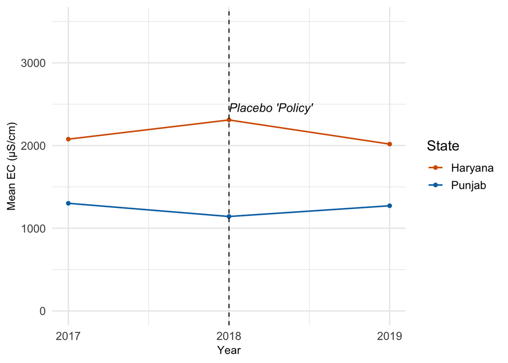

```r
placebo_data <- combination2 %>%
  filter(year %in% c(2017, 2018, 2019)) %>%
  mutate(year = as.numeric(year))

ec_summary <- placebo_data %>%
  group_by(state_name, year) %>%
  summarise(mean_ec = mean(electrical_conductivity, na.rm = TRUE), .groups = "drop")

max_2018 <- ec_summary %>% filter(year == 2018) %>% summarise(max_val = max(mean_ec)) %>% pull()
f <- ggplot(ec_summary, aes(x = year, y = mean_ec, color = state_name)) +
  geom_line(size = 0.7) +
  geom_point(size = 1.5) +
  geom_vline(xintercept = 2018, linetype = "dashed", color = "black") +
  annotate("text", x = 2018, y = max_2018 + 150,
           label = "Placebo 'Policy'", hjust = 0, size = 4.2, fontface = "italic") +
  scale_x_continuous(breaks = c(2017, 2018, 2019)) +
  scale_y_continuous(limits = c(0, 3500)) +
  scale_color_manual(
    values = c("Haryana" = "#D55E00", "Punjab" = "#0072B2")
  ) +
  labs(
    x = "Year",
    y = "Mean EC (μS/cm)",
    color = "State"
  ) +
  theme_minimal(base_size = 14) +
  theme(
    axis.title.x = element_text(size = 11),
    axis.title.y = element_text(size = 11),
    plot.title = element_text(face = "bold", hjust = 0.5),
    legend.position = "right"
  )
f
```

fixed-effect model：

```r
set.seed(123)
model_fe <- plm(
  electrical_conductivity ~ treated * post + factor(year),
  data = combination2,
  index = c("district_name", "year"),
  model = "within"
)
summary(model_fe)
```

```
## Oneway (individual) effect Within Model
##
## Call:
## plm(formula = electrical_conductivity ~ treated * post + factor(year),
##     data = combination2, model = "within", index = c("district_name",
##         "year"))
##
## Unbalanced Panel: n = 37, T = 3-6, N = 213
##
## Residuals:
##      Min.   1st Qu.    Median   3rd Qu.      Max.
## -1401.736  -262.201   -53.581   243.016  2029.762
##
## Coefficients: (1 dropped because of singularities)
##                   Estimate Std. Error t-value Pr(>|t|)
## post                1.4657   165.6775  0.0088  0.99295
## factor(year)2018   52.2632   139.0583  0.3758  0.70751
## factor(year)2019  -78.6460   143.0359 -0.5498  0.58315
## factor(year)2020   63.3926   144.3165  0.4393  0.66103
## factor(year)2021  239.0736   142.9374  1.6726  0.09625 .
## treated:post     -170.3302   165.6773 -1.0281  0.30537
## ---
## Signif. codes:  0 '***' 0.001 '**' 0.01 '*' 0.05 '.' 0.1 ' ' 1
##
## Total Sum of Squares:    62540000
## Residual Sum of Squares: 60816000
## R-Squared:      0.02758
## Adj. R-Squared: -0.21266
## F-statistic: 0.803605 on 6 and 170 DF, p-value: 0.56839
```

```r
vcov_cl <- vcovHC(model_fe, method = "arellano", cluster = "group")
out_fe1 <-  coeftest(model_fe, vcov = vcov_cl)
summary(out_fe1)
```

```
##     Estimate         Std. Error       t value            Pr(>|t|)
##  Min.   :-170.33   Min.   :109.4   Min.   :-1.31148   Min.   :0.1807
##  1st Qu.: -58.62   1st Qu.:118.1   1st Qu.:-0.47113   1st Qu.:0.2756
##  Median :  26.86   Median :122.7   Median : 0.22926   Median :0.5456
##  Mean   :  17.87   Mean   :129.9   Mean   : 0.07303   Mean   :0.5183
##  3rd Qu.:  60.61   3rd Qu.:128.5   3rd Qu.: 0.54610   3rd Qu.:0.6327
##  Max.   : 239.07   Max.   :177.9   Max.   : 1.34400   Max.   :0.9903
```

add more co-variabtes：

```r
set.seed(123)
model_fe2 <- plm(electrical_conductivity ~ treated * post + factor(year) + chloride + sodium + ph,
                 data = combination2,
                 model = "within",
                 index = c("district_name", "year"))
summary(model_fe2)
```

```
## Oneway (individual) effect Within Model
##
## Call:
## plm(formula = electrical_conductivity ~ treated * post + factor(year) +
##     chloride + sodium + ph, data = combination2, model = "within",
##     index = c("district_name", "year"))
##
## Unbalanced Panel: n = 37, T = 3-6, N = 213
##
## Residuals:
##      Min.   1st Qu.    Median   3rd Qu.      Max.
## -861.2097 -111.3998   -6.1712   83.2513  919.2368
##
## Coefficients: (1 dropped because of singularities)
##                    Estimate Std. Error t-value  Pr(>|t|)
## post              -67.72078   64.32559 -1.0528  0.293962
## factor(year)2018  -78.80281   53.30664 -1.4783  0.141213
## factor(year)2019 -122.65074   56.04982 -2.1882  0.030041 *
## factor(year)2020   23.53996   55.41764  0.4248  0.671548
## factor(year)2021  -81.31434   64.45001 -1.2617  0.208829
## chloride            2.64017    0.21532 12.2618 < 2.2e-16 ***
## sodium              2.05055    0.27325  7.5044 3.497e-12 ***
## ph               -222.50559   76.46213 -2.9100  0.004107 **
## treated:post     -142.80645   63.80026 -2.2383  0.026521 *
## ---
## Signif. codes:  0 '***' 0.001 '**' 0.01 '*' 0.05 '.' 0.1 ' ' 1
##
## Total Sum of Squares:    62540000
## Residual Sum of Squares: 8711900
## R-Squared:      0.8607
## Adj. R-Squared: 0.82316
## F-statistic: 114.65 on 9 and 167 DF, p-value: < 2.22e-16
```

```r
vcov_cl2 <- vcovHC(model_fe2, method = "arellano", cluster = "group")
out_fe2 <- coeftest(model_fe2, vcov = vcov_cl2)
out_fe2
```

```
##
## t test of coefficients:
##
##                    Estimate Std. Error t value  Pr(>|t|)
## post              -67.72078   41.30028 -1.6397 0.1029463
## factor(year)2018  -78.80281   36.92973 -2.1339 0.0343142 *
## factor(year)2019 -122.65074   35.80578 -3.4254 0.0007725 ***
## factor(year)2020   23.53996   59.11107  0.3982 0.6909674
## factor(year)2021  -81.31434   66.32757 -1.2260 0.2219431
## chloride            2.64017    0.40823  6.4673 1.057e-09 ***
## sodium              2.05055    0.42818  4.7890 3.675e-06 ***
## ph               -222.50559   46.16470 -4.8198 3.211e-06 ***
## treated:post     -142.80645   51.41447 -2.7776 0.0061036 **
## ---
## Signif. codes:  0 '***' 0.001 '**' 0.01 '*' 0.05 '.' 0.1 ' ' 1
```

```r
summary(out_fe2)
```

```
##     Estimate          Std. Error         t value           Pr(>|t|)
##  Min.   :-222.506   Min.   : 0.4082   Min.   :-4.8198   Min.   :0.0000000
##  1st Qu.:-122.651   1st Qu.:35.8058   1st Qu.:-2.7776   1st Qu.:0.0000037
##  Median : -78.803   Median :41.3003   Median :-1.6397   Median :0.0061036
##  Mean   : -76.397   Mean   :37.5433   Mean   :-0.4853   Mean   :0.1174504
##  3rd Qu.:   2.051   3rd Qu.:51.4145   3rd Qu.: 0.3982   3rd Qu.:0.1029463
##  Max.   :  23.540   Max.   :66.3276   Max.   : 6.4673   Max.   :0.6909674
```

### SDID

```r
set.seed(123)
sdid_data <- combination %>%
  group_by(district_name, year) %>%
  summarise(electrical_conductivity = mean(electrical_conductivity), .groups = "drop")

treated_districts <- combination %>%
  filter(treated == 1) %>%
  distinct(district_name) %>%
  pull(district_name)

sdid_data <- sdid_data %>%
  mutate(
    treated = ifelse(district_name %in% treated_districts, 1, 0),
    post = ifelse(year >= 2020, 1, 0),
  )

Y_wide <- sdid_data %>%
  select(district_name, year, electrical_conductivity) %>%
  pivot_wider(names_from = year, values_from = electrical_conductivity)

Y <- as.matrix(Y_wide[,-1])
rownames(Y) <- Y_wide$district_name

control_units <- setdiff(rownames(Y), treated_districts)
treated_units <- treated_districts
Y <- Y[c(control_units, treated_units), ]

Y <- apply(Y, 1, function(row) {
  if (anyNA(row)) {
    row[is.na(row)] <- mean(row, na.rm = TRUE)
  }
  return(row)
})
Y <- t(Y)


stopifnot(!anyNA(Y))

colnames(Y) <- as.numeric(colnames(Y))
Y <- Y[, order(as.numeric(colnames(Y)))]


control_units <- setdiff(rownames(Y), treated_districts)
treated_units <- treated_districts

Y <- Y[c(control_units, treated_units), ]

N0 <- length(control_units)
N1 <- length(treated_units)
T0 <- sum(as.numeric(colnames(Y)) < 2020)
```

```r
set.seed(123)
result <- synthdid_estimate(Y, N0 = N0, T0 = T0)
summary(result)
```

```
## $estimate
## [1] -180.1565
##
## $se
##          [,1]
## [1,] 141.2268
##
## $controls
##                 estimate 1
## Mansa                0.087
## Moga                 0.070
## Amritsar             0.070
## Patiala              0.069
## Sangrur              0.068
## Gurdaspur            0.067
## Jalandhar            0.065
## Barnala              0.060
## Pathankot            0.059
## Fatehgarh Sahib      0.057
## Hoshiarpur           0.056
## Kapurthala           0.056
## Ludhiana             0.054
## Tarn Taran           0.048
## Bathinda             0.046
##
## $periods
##      estimate 1
## 2019      0.377
## 2018      0.374
## 2017      0.249
##
## $dimensions
##           N1           N0 N0.effective           T1           T0 T0.effective
##       20.000       17.000       16.217        3.000        3.000        2.906
```

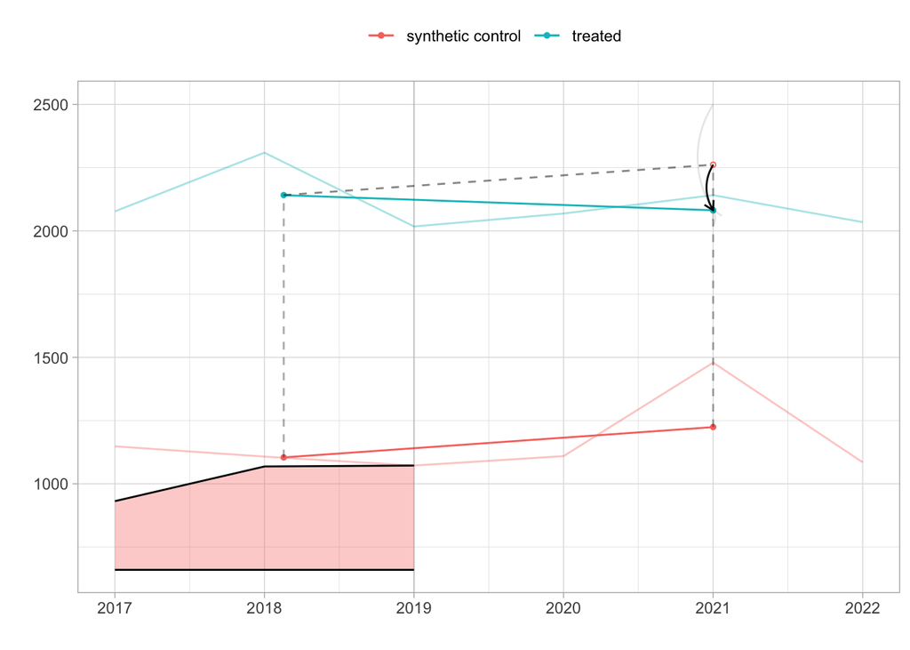

```r
k <- synthdid_plot(result)
k
```

```r
att <- summary(result)$estimate
se  <- summary(result)$se
ci_lower <- att - 1.96 * 135.489
ci_upper <- att + 1.96 * 135.489

cat("ATT =", round(att, 4), " | 95% CI:", round(ci_lower, 4), "~", round(ci_upper, 4), "\n")
```

```
## ATT = -180.1565  | 95% CI: -445.715 ~ 85.4019
```

### CausalImpact package

```r
set.seed(123)
haryana_ts <- haryana %>%
  group_by(year) %>%
  summarise(electrical_conductivity = mean(electrical_conductivity, na.rm = TRUE)) %>%
  arrange(year)

haryana_ts$year <- as.numeric(haryana_ts$year)
ts_mat <- as.matrix(haryana_ts$electrical_conductivity)
rownames(ts_mat) <- haryana_ts$year

pre.period <- c(1, 3)
post.period <- c(4, 6)

impact <- CausalImpact(ts_mat, pre.period, post.period)
summary(impact)
```

```
## Posterior inference {CausalImpact}
##
##                          Average          Cumulative
## Actual                   2068             6204
## Prediction (s.d.)        2178 (25)        6533 (76)
## 95% CI                   [2127, 2226]     [6382, 6677]
##
## Absolute effect (s.d.)   -110 (25)        -329 (76)
## 95% CI                   [-158, -59]      [-473, -178]
##
## Relative effect (s.d.)   -5% (1.1%)       -5% (1.1%)
## 95% CI                   [-7.1%, -2.8%]   [-7.1%, -2.8%]
##
## Posterior tail-area probability p:   0.00203
## Posterior prob. of a causal effect:  99.79675%
##
## For more details, type: summary(impact, "report")
```

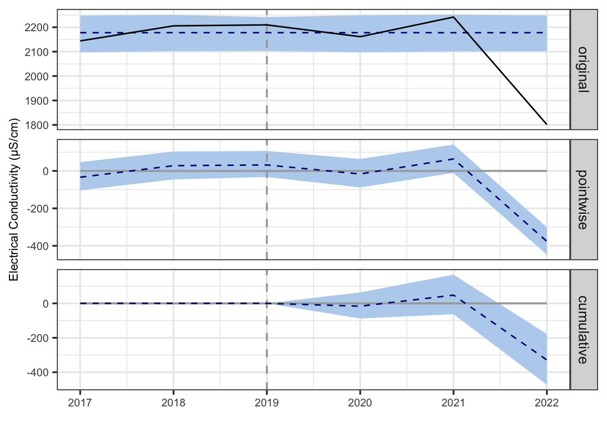

```r
a <- plot(impact)
a <- a + ylab("Electrical Conductivity (µS/cm)")
summary_text <- capture.output(summary(impact))


a <- a +
  scale_x_continuous(breaks = 1:6, labels = 2017:2022) +
  ylab("Electrical Conductivity (µS/cm)") +
  theme(
    axis.title.x = element_text(size = 10),
    axis.title.y = element_text(size = 10),
    axis.text.x  = element_text(size = 9),
    axis.text.y  = element_text(size = 9)
  )

a
```

Using punjab as control group

```r
set.seed(123)
ts <- combination %>%
  group_by(year) %>%
  summarise(
    haryana_ec = mean(electrical_conductivity[treated == 1], na.rm = TRUE),
    punjab_ec = mean(electrical_conductivity[treated == 0], na.rm = TRUE),
    .groups = "drop"
  ) %>%
  arrange(year)


ts_mat <- as.matrix(ts[, c("haryana_ec", "punjab_ec")])
rownames(ts_mat) <- ts$year

pre.period <- c(1, 3)
post.period <- c(4, 6)

impact <- CausalImpact(ts_mat, pre.period, post.period)
summary(impact)
```

```
## Posterior inference {CausalImpact}
##
##                          Average         Cumulative
## Actual                   2068            6204
## Prediction (s.d.)        2179 (13)       6537 (40)
## 95% CI                   [2153, 2206]    [6460, 6617]
##
## Absolute effect (s.d.)   -111 (13)       -333 (40)
## 95% CI                   [-138, -85]     [-413, -256]
##
## Relative effect (s.d.)   -5.1% (0.58%)   -5.1% (0.58%)
## 95% CI                   [-6.2%, -4%]    [-6.2%, -4%]
##
## Posterior tail-area probability p:   0.00103
## Posterior prob. of a causal effect:  99.89744%
##
## For more details, type: summary(impact, "report")
```

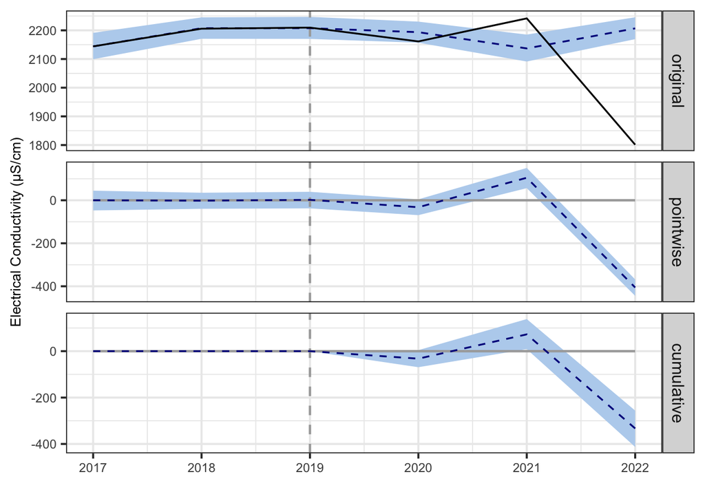

```r
b <- plot(impact)


b <- b +
  scale_x_continuous(breaks = 1:6, labels = 2017:2022) +
  ylab("Electrical Conductivity (µS/cm)") +
  theme(
    axis.title.x = element_text(size = 10),
    axis.title.y = element_text(size = 10),
    axis.text.x  = element_text(size = 9),
    axis.text.y  = element_text(size = 9)
  )

b
```

Add covariates:

```r
set.seed(123)
ts_add <- combination %>%
  group_by(year) %>%
  summarise(
    haryana_ec = mean(electrical_conductivity[treated == 1], na.rm = TRUE),
    punjab_ec = mean(electrical_conductivity[treated == 0], na.rm = TRUE),
    chloride = mean(chloride, na.rm = TRUE),
    sodium = mean(sodium, na.rm = TRUE),
    .groups = "drop"
  ) %>%
  arrange(year)

ts_mat_add <- as.matrix(ts_add[, -1])
rownames(ts_mat_add) <- ts_add$year

pre.period <- c(1, 3)
post.period <- c(4, 6)

impact <- CausalImpact(ts_mat_add, pre.period, post.period)
summary(impact)
```

```
## Posterior inference {CausalImpact}
##
##                          Average          Cumulative
## Actual                   2068             6204
## Prediction (s.d.)        2199 (35)        6596 (105)
## 95% CI                   [2117, 2255]     [6352, 6764]
##
## Absolute effect (s.d.)   -130 (35)        -391 (105)
## 95% CI                   [-186, -49]      [-559, -148]
##
## Relative effect (s.d.)   -5.9% (1.5%)     -5.9% (1.5%)
## 95% CI                   [-8.3%, -2.3%]   [-8.3%, -2.3%]
##
## Posterior tail-area probability p:   0.003
## Posterior prob. of a causal effect:  99.7%
##
## For more details, type: summary(impact, "report")
```

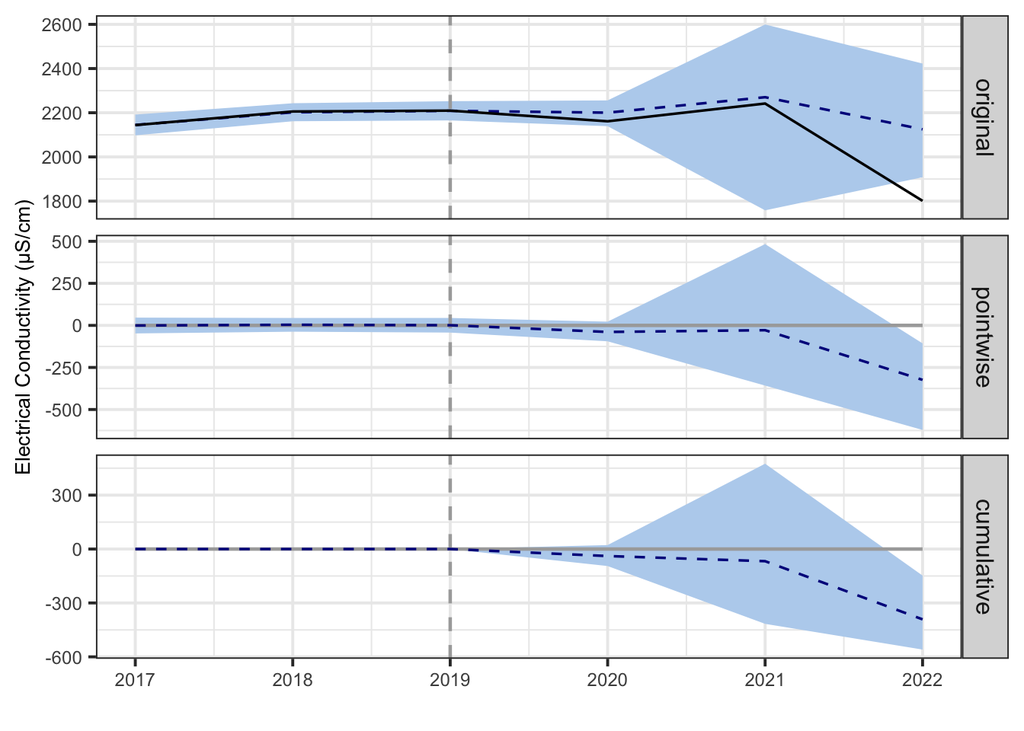

```r
c <- plot(impact)


c <- c +
  scale_x_continuous(breaks = 1:6, labels = 2017:2022) +
  ylab("Electrical Conductivity (µS/cm)") +
  theme(
    axis.title.x = element_text(size = 10),
    axis.title.y = element_text(size = 10),
    axis.text.x  = element_text(size = 9),
    axis.text.y  = element_text(size = 9)
  )

c
```